# Sleep More

```r
# Load your libraries
library(car)
library(tidyverse)
library(mosaic)
library(pander)
library(DT)
library(plotly)


# Load your data after saving a csv file in your Data folder.
# You can use either
Sleep2 <- read.csv("../../Data/Sleep2.csv", header=TRUE)
# or
#library(readr)
#Sleep2 <- read_csv("../../Data/Sleep2.csv")

# Don't forget to run "Session -> Set Working Directory -> To Source file location"
```

## Background

Is there a significant correlation between the normality of my heartbeat and the total amount of sleep I get?

It is generally assumed that more sleep (up to a certain point) equates to healthier sleep. The true regression slope is shown below:

$$\underbrace{Y_i}_\text{Sleep Rhythm Percentage} = \beta_0 + \beta_1 \underbrace{X_i}_\text{Hours of Sleep} + \epsilon_i \quad \text{where} \ \epsilon_i \sim N(0, \sigma^2)$$

## Data

The data used in this study was collected via an Apple Watch, using an app called “SleepWatch”. This app monitors various factors that are related to sleep health and quality, such as total time, heart rate dip, restful sleep amount, and sleep rhythm. I selected to use the data recorded on my total sleep time and the sleep rhythm. Sleep rhythm is defined as the percentage of the total sleep time that my heartbeat is regular. To select the days to use in the test, I went back approximately 15 weeks to October, and then used a random number generator to select the date in October to begin with. The generator output 15, so I began with the 15th day of October. I then used a systematic random sampling method, recording every 8th day. I selected every 8th day in order to include data for every day of the week since I know that my sleep patterns are different throughout week than they are over the weekend. I ended up with 17 days worth of data, including 3 of the days of Tuesday, Wednesday and Thursday, and 2 data points for each of the other days of the week.

## Hypotheses

The following regression analysis concerns the slope of our regression model, $\beta_1$, which we will compare to 0. If the slope of our regression line is 0, then there is no significant correlation between sleep time and heartbeat rhythm. This is shown by our hypotheses below:

$$H_O: \beta_1 = 0$$

$$H_A: \beta_1 \neq 0$$

The significance level for this test will be set at
$$\alpha = 0.01$$

## Analysis

```r
sleep2lm2 <- lm(Rhythm ~ Sleep, data = Sleep2)
```

### Diagnostic Plots

The following graphs show whether the qualifications for this test were satisfied. The residuals vs fitted plot does show we have a possible issue with the linear relationship between X and Y, but we decided it was not significant enough to discredit the results of the test. This plot also shows that we have approximately equal variance. The QQ-Plot shows us that the residuals are normal. The Residuals vs Order plot shows us that the errors are independent of each other and we can thus continue with the test.

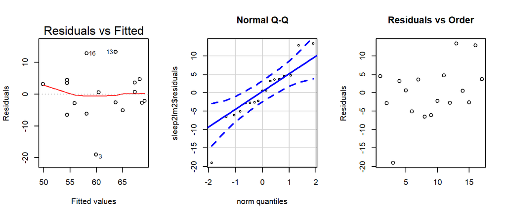

```r
par(mfrow=c(1,3))
plot(sleep2lm2,which=1)
qqPlot(sleep2lm2$residuals, id = FALSE, main = "Normal Q-Q")
plot(sleep2lm2$residuals, main = "Residuals vs Order", xlab = "", ylab = "Residuals")
```

### Graphical Summary

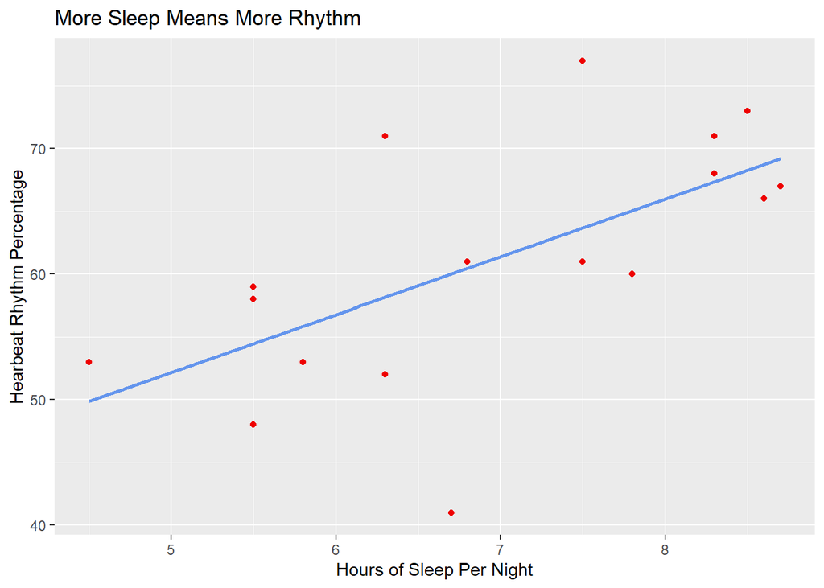

```r
ggplot(Sleep2, aes(x = Sleep, y = Rhythm))+
  geom_point(color = "red2", pch = 19)+
  geom_smooth(method = "lm", se=FALSE, color = "cornflowerblue")+
  labs(x = "Hours of Sleep Per Night", y = "Hearbeat Rhythm Percentage", title = "More Sleep Means More Rhythm")+
  theme(legend.position = "none")+
  theme_update()
```

```r
summary(sleep2lm2) %>%
  pander(caption = "Summary of the linear regression test")
```

|  | Estimate | Std. Error | t value | Pr(>\|t\|) |
| --- | --- | --- | --- | --- |
| **(Intercept)** | 29.17 | 10.48 | 2.783 | 0.01393 |
| **Sleep** | 4.599 | 1.484 | 3.1 | 0.007316 |

Summary of the linear regression test

| Observations | Residual Std. Error | $R^2$ | Adjusted $R^2$ |
| --- | --- | --- | --- |
| 17 | 7.812 | 0.3905 | 0.3499 |

## Conclusion

Below is the approximated linear model of the relationship between the amount of sleep and normal heartbeat percentage during sleep based on the results of our regression test.

$$\text{Estimated Sleep Rhythm Percentage} = \text{29.17 + 4.6(Hours of Sleep)}$$
With our computed p-value of $p = 0.007316 < \alpha = .01$, we can reject our null hypothesis that the true slope of the regression line is 0. The results show us that for each additional hour of sleep achieved, the change in average sleep percentage is 4.6. We, therefore, have sufficient evidence to conclude that the true regression slope is not zero, but that it is 4.6. With regards to my initial study question, there is a significant correlation between the amount of sleep I get and my heartbeat rhythm percentage.

For those interested, here is a numerical summary of all the data used, organized by the date of the morning the data was collected.

```r
datatable(Sleep2, options=list(lengthMenu = c(3,7,17)))
```

|  | Date | Sleep | Rhythm |
| --- | --- | --- | --- |
| 1 | 15-Oct | 5.5 | 59 |
| 2 | 23-Oct | 5.8 | 53 |
| 3 | 31-Oct | 6.7 | 41 |
| 4 | 8-Nov | 4.5 | 53 |
| 5 | 16-Nov | 8.3 | 68 |
| 6 | 24-Nov | 7.8 | 60 |
| 7 | 2-Dec | 5.5 | 58 |
| 8 | 10-Dec | 5.5 | 48 |
| 9 | 18-Dec | 6.3 | 52 |
| 10 | 26-Dec | 8.7 | 67 |

[output cut: 7 more lines]